# Project: Investigate a Dataset (No Show Medical Appointments in Brazil)

- Introduction
- Data Wrangling
  - Data Gathering
  - Data Assessing
  - Data Cleaning
- Exploratory Data Analysis
- Conclusions

## Introduction

In this project, I have analysed "No show appointments" dataset, which is available on Kaggle. This dataset collects information from 100k medical appointments in Brazil.

The dataset includes,

- Patient details - Patient ID, Gender, Age, Neighbourhood, Scholarship, Whether the patient has Hipertension, Diabetes and Whether the patient is Alcoholic and Handicap
- Appointment details - Appointment ID, Appointment Scheduled Day, Appointment Day, SMS_received and No-show (whether the patient showed up or not)

**Note**: Findings are **tentative** as inferential statistics or machine learning are not used to complete this project

**Questions focused to be answered,**

- Patients with which disease schedules appoinments and doesn't shows up the most?
- How does the number of SMS received affects the show-up for scheduled appoinments?
- How does Gender affects the No Show occurence?
- How does Scholarship affects the No Show occurence?
- How does Age affects the No Show rate?
- Does the gap between scheduled date and appointment date affect patient's no-show rate?
- Does the Day of the week affect patient no-show probability?
- What factors are important for us to know in order to predict if a patient will show up for their scheduled appointment?

```python
# Import required packages
import pandas as pd
import numpy as np
import matplotlib.pyplot as plt
import seaborn as sns
import requests
import datetime as dt

# To plot visualizations inline with the notebook
%matplotlib inline
```

## Data Wrangling

### Data Gathering

> - Download the [csv file ("no_show_appointments")](https://d17h27t6h515a5.cloudfront.net/topher/2017/October/59dd2e9a_noshowappointments-kagglev2-may-2016/noshowappointments-kagglev2-may-2016.csv) from Kaggle programmatically
> - Load the downloaded file into DataFrame

```python
# Request csv file from the url
url = "https://d17h27t6h515a5.cloudfront.net/topher/2017/October/59dd2e9a_noshowappointments-kagglev2-may-2016/noshowappointments-kagglev2-may-2016.csv"
response = requests.get(url)

# Write the response into csv file
with open('no_show_appointments.csv', mode='wb') as file:
    file.write(response.content)

# Load data from the file into DataFrame and print out a few lines.
df = pd.read_csv('no_show_appointments.csv')
df.head()
```

|  | PatientId | AppointmentID | Gender | ScheduledDay | AppointmentDay | Age | Neighbourhood | Scholarship | Hipertension | Diabetes | Alcoholism | Handcap | SMS_received | No-show |
| --- | --- | --- | --- | --- | --- | --- | --- | --- | --- | --- | --- | --- | --- | --- |
| 0 | 2.987250e+13 | 5642903 | F | 2016-04-29T18:38:08Z | 2016-04-29T00:00:00Z | 62 | JARDIM DA PENHA | 0 | 1 | 0 | 0 | 0 | 0 | No |
| 1 | 5.589978e+14 | 5642503 | M | 2016-04-29T16:08:27Z | 2016-04-29T00:00:00Z | 56 | JARDIM DA PENHA | 0 | 0 | 0 | 0 | 0 | 0 | No |
| 2 | 4.262962e+12 | 5642549 | F | 2016-04-29T16:19:04Z | 2016-04-29T00:00:00Z | 62 | MATA DA PRAIA | 0 | 0 | 0 | 0 | 0 | 0 | No |
| 3 | 8.679512e+11 | 5642828 | F | 2016-04-29T17:29:31Z | 2016-04-29T00:00:00Z | 8 | PONTAL DE CAMBURI | 0 | 0 | 0 | 0 | 0 | 0 | No |
| 4 | 8.841186e+12 | 5642494 | F | 2016-04-29T16:07:23Z | 2016-04-29T00:00:00Z | 56 | JARDIM DA PENHA | 0 | 1 | 1 | 0 | 0 | 0 | No |

### Data Assessing

> - Number of samples and features
> - Perform operations to inspect data types
> - Look for instances of missing or possibly errant data
> - Look for instances of duplicates
> - Perform operations to inspect number of uniques values in each column
> - Perform operations to inspect uniques values in each column

```python
# Number of samples and features
print('Number of samples :', df.shape[0])
print('Number of features :', df.shape[1])
```

```
Number of samples : 110527
Number of features : 14
```

```python
# Perform operations to inspect data types
df.dtypes
```

```
PatientId         float64
AppointmentID       int64
Gender             object
ScheduledDay       object
AppointmentDay     object
Age                 int64
Neighbourhood      object
Scholarship         int64
Hipertension        int64
Diabetes            int64
Alcoholism          int64
Handcap             int64
SMS_received        int64
No-show            object
dtype: object
```

> - checking the datatype of values which are of object in above step

```python
print('Gender :', type(df.Gender[0]))
print('ScheduledDay :', type(df.ScheduledDay[0]))
print('AppointmentDay :', type(df.AppointmentDay[0]))
print('Neighbourhood :', type(df.Neighbourhood[0]))
```

```
Gender : <class 'str'>
ScheduledDay : <class 'str'>
AppointmentDay : <class 'str'>
Neighbourhood : <class 'str'>
```

> **Note :**
> - Wrong column naming conventions for "No-show" column name
> - 'ScheduledDay' & 'AppointmentDay' is of type *string*
> - 'Handicap' mispelled as 'Handcap'
> - Lowercase columns names would be more easier during analysis

```python
# look for instances of missing or possibly errant data
df.info()
```

```
<class 'pandas.core.frame.DataFrame'>
RangeIndex: 110527 entries, 0 to 110526
Data columns (total 14 columns):
 #   Column          Non-Null Count   Dtype
---  ------          --------------   -----
 0   PatientId       110527 non-null  float64
 1   AppointmentID   110527 non-null  int64
 2   Gender          110527 non-null  object
 3   ScheduledDay    110527 non-null  object
 4   AppointmentDay  110527 non-null  object
 5   Age             110527 non-null  int64
 6   Neighbourhood   110527 non-null  object
 7   Scholarship     110527 non-null  int64
 8   Hipertension    110527 non-null  int64
 9   Diabetes        110527 non-null  int64
 10  Alcoholism      110527 non-null  int64
 11  Handcap         110527 non-null  int64
 12  SMS_received    110527 non-null  int64
 13  No-show         110527 non-null  object
dtypes: float64(1), int64(8), object(5)
memory usage: 11.8+ MB
```

```python
# Look for instances of duplicates
df.duplicated().value_counts()
```

```
False    110527
dtype: int64
```

```python
# Perform operations to inspect number of uniques values in each column
df.nunique()
```

```
PatientId          62299
AppointmentID     110527
Gender                 2
ScheduledDay      103549
AppointmentDay        27
Age                  104
Neighbourhood         81
Scholarship            2
Hipertension           2
Diabetes               2
Alcoholism             2
Handcap                5
SMS_received           2
No-show                2
dtype: int64
```

**Checking the unique values in each column,**

> - As per the dataset definition in [Kaggle](https://www.kaggle.com/joniarroba/noshowappointments), Handcap must have values either True/False. But in the assessed DataFrame, 5 unique values are found.
> - And also, SMS_received can have more than 1 unique values.
> - So, checking the unique values of each column for data consistency
> - **Avoided columns :** PatientId & AppointmentID as it will be not used in analysis

```python
# Unique values in Handcap
df.Handcap.unique()
```

```
array([0, 1, 2, 3, 4], dtype=int64)
```

```python
# Unique values in SMS_received
df.SMS_received.unique()
```

```
array([0, 1], dtype=int64)
```

> **Note :** It is clear that the Handcap & SMS_received column values may have swapped, as per the dataset definition in [Kaggle](https://www.kaggle.com/joniarroba/noshowappointments)

```python
# Unique values in Gender
df.Gender.unique()
```

```
array(['F', 'M'], dtype=object)
```

```python
# Unique values in Age
df.Age.unique()
```

```
array([ 62,  56,   8,  76,  23,  39,  21,  19,  30,  29,  22,  28,  54,
        15,  50,  40,  46,   4,  13,  65,  45,  51,  32,  12,  61,  38,
        79,  18,  63,  64,  85,  59,  55,  71,  49,  78,  31,  58,  27,
         6,   2,  11,   7,   0,   3,   1,  69,  68,  60,  67,  36,  10,
        35,  20,  26,  34,  33,  16,  42,   5,  47,  17,  41,  44,  37,
        24,  66,  77,  81,  70,  53,  75,  73,  52,  74,  43,  89,  57,
        14,   9,  48,  83,  72,  25,  80,  87,  88,  84,  82,  90,  94,
        86,  91,  98,  92,  96,  93,  95,  97, 102, 115, 100,  99,  -1],
      dtype=int64)
```

> **Note :** Calculating the proportion of Age (102,115,100) in order to decide whether it is normal

```python
# Number of patients is of Age (102,115,100)
count = df.query('Age in [102,115,100]').Age.count()
count
```

```
11
```

```python
# Total samples
total_samples = df.shape[0]
total_samples
```

```
110527
```

```python
# Proportion of Age (102,115,100)
proportion = count/total_samples
proportion
```

```
9.952319342785021e-05
```

> **Note :** Age must be greater than 0
> - (0,-1) inaccurate data
> - Considering the Ages (102,115,100) as its proportion is too low and we know some humans live after 100 years old.

```python
# Unique values in Scholarship
df.Scholarship.unique()
```

```
array([0, 1], dtype=int64)
```

```python
# Unique values in Hipertension
df.Hipertension.unique()
```

```
array([1, 0], dtype=int64)
```

```python
# Unique values in Diabetes
df.Diabetes.unique()
```

```
array([0, 1], dtype=int64)
```

```python
# Unique values in Alcoholism
df.Alcoholism.unique()
```

```
array([0, 1], dtype=int64)
```

```python
# Unique values in ScheduledDay
df.ScheduledDay.unique()
```

```
array(['2016-04-29T18:38:08Z', '2016-04-29T16:08:27Z',
       '2016-04-29T16:19:04Z', ..., '2016-04-27T16:03:52Z',
       '2016-04-27T15:09:23Z', '2016-04-27T13:30:56Z'], dtype=object)
```

```python
# Unique values in AppointmentDay
df.AppointmentDay.unique()
```

```
array(['2016-04-29T00:00:00Z', '2016-05-03T00:00:00Z',
       '2016-05-10T00:00:00Z', '2016-05-17T00:00:00Z',
       '2016-05-24T00:00:00Z', '2016-05-31T00:00:00Z',
       '2016-05-02T00:00:00Z', '2016-05-30T00:00:00Z',
       '2016-05-16T00:00:00Z', '2016-05-04T00:00:00Z',
       '2016-05-19T00:00:00Z', '2016-05-12T00:00:00Z',
       '2016-05-06T00:00:00Z', '2016-05-20T00:00:00Z',
       '2016-05-05T00:00:00Z', '2016-05-13T00:00:00Z',
       '2016-05-09T00:00:00Z', '2016-05-25T00:00:00Z',
       '2016-05-11T00:00:00Z', '2016-05-18T00:00:00Z',
       '2016-05-14T00:00:00Z', '2016-06-02T00:00:00Z',
       '2016-06-03T00:00:00Z', '2016-06-06T00:00:00Z',
       '2016-06-07T00:00:00Z', '2016-06-01T00:00:00Z',
       '2016-06-08T00:00:00Z'], dtype=object)
```

**Observations based on Assessing the dataset :**

> **Columns :**
> - Unrequired columns, PatientId & AppointmentID
> - Wrong column naming conventions for "No-show" column name
> - 'Handicap' mispelled as 'Handcap'
> - Lowercase columns names would be more easier during analysis

> **Datatype :**
> - 'ScheduledDay' & 'AppointmentDay' is of type string, should be changed to DateTime

> **Data :**
> - It is clear that the Handcap & SMS_received column values may have swapped, as per the dataset definition in [Kaggle](https://www.kaggle.com/joniarroba/noshowappointments)
> - Inaccurate data in Age (0,-1)
> - Because of wrong column name conventions, couldn't assess the unique values in 'no_show'. But column says ‘No’ if the patient showed up to their appointment, and ‘Yes’ if they did not show up, should be changed as, 'No'-1 & 'Yes'-0, as it is in encrypted form. Refer [here](https://s3.amazonaws.com/video.udacity-data.com/topher/2018/July/5b57919a_data-set-options/data-set-options.pdf)

### Data Cleaning

> **Columns :**
> - Drop Unrequired columns, 'PatientId' & 'AppointmentID'
> - Change the column name of *'No-show' - 'no_show'* and *'Handcap' - 'handicap'*
> - Change columns names to Lowercase & Insert _ before day in ScheduledDay & AppointmentDay

> **Datatype :**
> - Change datatype of 'ScheduledDay' & 'AppointmentDay', from *string* to *DateTime*

> **Data :**
> - Swap the values among 'handicap' & 'sms_received' columns
> - Fill in inaccurate data in 'age' (0,-1) with age mean
> - Change the value in 'no_show' column 'No'-1 & 'Yes'-0 of integer type, as it is in encrypted form. Refer [here](https://s3.amazonaws.com/video.udacity-data.com/topher/2018/July/5b57919a_data-set-options/data-set-options.pdf)

> **Feature Engineering :**
> - Create a column named 'awaiting_days' for easier analysis, which is the difference between scheduled & appointment day

### Issue 1

#### Define :

```
Drop unrequired columns, 'PatientId' & 'AppointmentID', as it will be not used in analysis
```

#### Clean :

```python
# Check columns before drop
print('Number of columns before drop :', df.shape[1])
df.columns
```

```
Number of columns before drop : 14
```

```
Index(['PatientId', 'AppointmentID', 'Gender', 'ScheduledDay',
       'AppointmentDay', 'Age', 'Neighbourhood', 'Scholarship', 'Hipertension',
       'Diabetes', 'Alcoholism', 'Handcap', 'SMS_received', 'No-show'],
      dtype='object')
```

```python
# Drop the columns from DataFrame
df.drop(['PatientId','AppointmentID'], axis=1, inplace=True)
```

#### Test :

```python
# Check whether the columns are dropped from DataFrame
df.columns.all() in ['PatientId', 'AppointmentID']  # should return false
```

```
False
```

```python
# Columns after drop
print('Number of columns after drop :', df.shape[1])
df.columns
```

```
Number of columns after drop : 12
```

```
Index(['Gender', 'ScheduledDay', 'AppointmentDay', 'Age', 'Neighbourhood',
       'Scholarship', 'Hipertension', 'Diabetes', 'Alcoholism', 'Handcap',
       'SMS_received', 'No-show'],
      dtype='object')
```

### Issue 2

#### Define :

```
Change the column name of 'No-show' - 'no_show' (Wrong naming convention) and 'Handcap' - 'handicap'
```

#### Clean :

```python
# Renaming column names
df.rename(columns = {
    'No-show' : 'no_show',
    'Handcap' : 'handicap'
}, inplace=True);
```

#### Test :

```python
# Check whether the old name is not present
df.columns.all() in ['No-show', 'Handcap']  # should return false
```

```
False
```

```python
# columns names
df.columns
```

```
Index(['Gender', 'ScheduledDay', 'AppointmentDay', 'Age', 'Neighbourhood',
       'Scholarship', 'Hipertension', 'Diabetes', 'Alcoholism', 'handicap',
       'SMS_received', 'no_show'],
      dtype='object')
```

```python
# Check for the unique data, as we couldn't earlier (Because of naming conventions)
df.no_show.unique()
```

```
array(['No', 'Yes'], dtype=object)
```

### Issue 3

#### Define :

- Change columns names to Lowercase
- Insert _ before day in ScheduledDay & AppointmentDay

#### Clean :

```python
# Column names
df.columns
```

```
Index(['Gender', 'ScheduledDay', 'AppointmentDay', 'Age', 'Neighbourhood',
       'Scholarship', 'Hipertension', 'Diabetes', 'Alcoholism', 'handicap',
       'SMS_received', 'no_show'],
      dtype='object')
```

```python
# Rename columns names - to lowercase & insert underscore '_' before Day in ScheduledDay & AppointmentDay
df.rename(columns = lambda x : (x.split('Day')[0]+'_day').lower() if 'Day' in x else x.lower(), inplace=True)
```

#### Test :

```python
# Check whether the names are changed
df.columns
```

```
Index(['gender', 'scheduled_day', 'appointment_day', 'age', 'neighbourhood',
       'scholarship', 'hipertension', 'diabetes', 'alcoholism', 'handicap',
       'sms_received', 'no_show'],
      dtype='object')
```

### Issue 4

#### Define :

```
Change datatype of 'scheduled_day' & 'appointment_day', from string to Timestamp
```

#### Clean :

```python
# Change datatype from string to timestamp using datetime package
df.scheduled_day = df.scheduled_day.apply(lambda x : dt.datetime.strptime(x,"%Y-%m-%dT%H:%M:%SZ"))
df.appointment_day = df.appointment_day.apply(lambda x : dt.datetime.strptime(x,"%Y-%m-%dT%H:%M:%SZ"))
```

#### Test :

```python
# Check if the datatype is changed
type(df.scheduled_day[0]) , df.appointment_day[0]
```

```
(pandas._libs.tslibs.timestamps.Timestamp, Timestamp('2016-04-29 00:00:00'))
```

### Issue 5

#### Define :

```
Swap the values among 'handicap' & 'sms_received' columns
```

#### Clean :

```python
# list out few lines
df.head()
```

|  | gender | scheduled_day | appointment_day | age | neighbourhood | scholarship | hipertension | diabetes | alcoholism | handicap | sms_received | no_show |
| --- | --- | --- | --- | --- | --- | --- | --- | --- | --- | --- | --- | --- |
| 0 | F | 2016-04-29 18:38:08 | 2016-04-29 | 62 | JARDIM DA PENHA | 0 | 1 | 0 | 0 | 0 | 0 | No |
| 1 | M | 2016-04-29 16:08:27 | 2016-04-29 | 56 | JARDIM DA PENHA | 0 | 0 | 0 | 0 | 0 | 0 | No |
| 2 | F | 2016-04-29 16:19:04 | 2016-04-29 | 62 | MATA DA PRAIA | 0 | 0 | 0 | 0 | 0 | 0 | No |
| 3 | F | 2016-04-29 17:29:31 | 2016-04-29 | 8 | PONTAL DE CAMBURI | 0 | 0 | 0 | 0 | 0 | 0 | No |
| 4 | F | 2016-04-29 16:07:23 | 2016-04-29 | 56 | JARDIM DA PENHA | 0 | 1 | 1 | 0 | 0 | 0 | No |

```python
# Unique values in 'handicap' & 'sms_received' before swap
df.handicap.unique() , df.sms_received.unique()
```

```
(array([0, 1, 2, 3, 4], dtype=int64), array([0, 1], dtype=int64))
```

```python
# Swap by storing the copy of one column value temporarily
temp = df.handicap.copy()
df.handicap = df.sms_received
df.sms_received = temp
```

#### Test :

```python
# Unique values after swap
df.handicap.unique() , df.sms_received.unique()
```

```
(array([0, 1], dtype=int64), array([0, 1, 2, 3, 4], dtype=int64))
```

### Issue 6

#### Define :

```
Fill in inaccurate data in 'age' (0,-1) with age mean
```

#### Clean :

```python
# Number of samples
df.shape[0]
```

```
110527
```

```python
# Counts of each age
df.age.value_counts()
```

```
 0      3539
 1      2273
 52     1746
 49     1652
 53     1651
        ...
 115       5
 100       4
 102       2
 99        1
-1         1
Name: age, Length: 104, dtype: int64
```

```python
# Number of inaccurate data
print('Number of inaccurate data for age[0,-1] :',df.query('age in [0,-1]').count().age)

# Proportion of inaccurate data
print('Proportion of inaccurate data for age[0,-1] :',df.query('age in [0,-1]').count().age / df.shape[0])
```

```
Number of inaccurate data for age[0,-1] : 3540
Proportion of inaccurate data for age[0,-1] : 0.03202837315768998
```

> **Note :**
> - Age 0 has sample count of 3539 out of 110527, which has a proportion of 0.0320
> - As the proportion is low, fill in with mean age

```python
# Change value of age in [0,-1] to age.mean
mean_age = int(df.age.mean())
df.age = df.age.apply(lambda x : mean_age if x in [0,-1] else x)
```

```python
# The below query should be returned empty after drop
df.query('age in [0,-1]')
```

|  | gender | scheduled_day | appointment_day | age | neighbourhood | scholarship | hipertension | diabetes | alcoholism | handicap | sms_received | no_show |
| --- | --- | --- | --- | --- | --- | --- | --- | --- | --- | --- | --- | --- |

#### Test :

```python
# number of samples after dropping the patient details
df.shape[0]
```

```
110527
```

```python
# Check that the column 'age' has no value of 0/-1
df.age.all() in [0,-1]    # should return False
```

```
False
```

### Issue 7

#### Define :

```
Change the data in 'no_show' column as, 'No'-1 & 'Yes'-0 of integer type
```

#### Clean :

```python
# number of unique values in 'no_show' before change
df.no_show.value_counts()
```

```
No     88208
Yes    22319
Name: no_show, dtype: int64
```

```python
# Change value 'No'=1 & 'Yes'=0 of type int
df.no_show = df.no_show.apply(lambda x : int(1) if x=='No' else int(0))
```

### Test :

```python
# Check the number of unique value after value change
df.no_show.value_counts()
```

```
1    88208
0    22319
Name: no_show, dtype: int64
```

```python
# Check the datatype
df.no_show.dtype
```

```
dtype('int64')
```

### Feature Engineering :

#### Define :

```
Create a column named 'awaiting_days' for easier analysis, which is the difference between scheduled & appointment day
```

#### Create :

```python
# Difference between scheduled_day & appointment_day
df.scheduled_day - df.appointment_day
```

```
0           0 days 18:38:08
1           0 days 16:08:27
2           0 days 16:19:04
3           0 days 17:29:31
4           0 days 16:07:23
                ...
110522   -35 days +09:15:35
110523   -35 days +07:27:33
110524   -41 days +16:03:52
110525   -41 days +15:09:23
110526   -41 days +13:30:56
Length: 110527, dtype: timedelta64[ns]
```

> **Note :** As we can see the result in previous step as,
> - Some results are positive, some are negative
> - So, create a column *'awaiting_days'*, which is the result of absolute difference between scheduled_day & appointment_day

```python
# Feature creation
df['awaiting_days'] = abs(df.scheduled_day - df.appointment_day).dt.days
```

#### Test :

```python
# Check if the feature is created
df.tail()
```

|  | gender | scheduled_day | appointment_day | age | neighbourhood | scholarship | hipertension | diabetes | alcoholism | handicap | sms_received | no_show | awaiting_days |
| --- | --- | --- | --- | --- | --- | --- | --- | --- | --- | --- | --- | --- | --- |
| 110522 | F | 2016-05-03 09:15:35 | 2016-06-07 | 56 | MARIA ORTIZ | 0 | 0 | 0 | 0 | 1 | 0 | 1 | 34 |
| 110523 | F | 2016-05-03 07:27:33 | 2016-06-07 | 51 | MARIA ORTIZ | 0 | 0 | 0 | 0 | 1 | 0 | 1 | 34 |
| 110524 | F | 2016-04-27 16:03:52 | 2016-06-07 | 21 | MARIA ORTIZ | 0 | 0 | 0 | 0 | 1 | 0 | 1 | 40 |
| 110525 | F | 2016-04-27 15:09:23 | 2016-06-07 | 38 | MARIA ORTIZ | 0 | 0 | 0 | 0 | 1 | 0 | 1 | 40 |
| 110526 | F | 2016-04-27 13:30:56 | 2016-06-07 | 54 | MARIA ORTIZ | 0 | 0 | 0 | 0 | 1 | 0 | 1 | 40 |

```python
# Check the datatype of newly created feature
type(df.awaiting_days[0])
```

```
numpy.int64
```

**Store the cleaned data in new file,**

```python
df.to_csv('no_show_cleaned.csv', index=False)
```

## Exploratory Data Analysis

```python
# Load cleaned data into the DataFrame
df = pd.read_csv('no_show_cleaned.csv',
                 parse_dates=['scheduled_day', 'appointment_day'],
                 infer_datetime_format=True)
```

### Research Question 1 : Patients with which disease schedules appoinments and doesn't shows up the most?

```python
# Diseases formed as an numpy array for further calculation
diseases = np.array(['alcoholism','diabetes','hipertension','handicap'])
```

```python
# total number of patients appointments
total_count = df.shape[0]
total_count
```

```
110527
```

```python
# total number of patients didn't show up for appointments
total_noshowup = df.no_show.value_counts()[0]

# total number of patients show up
total_showup = df.no_show.value_counts()[1]
```

> **Process :**
> - Now that, we have value of total number of patients, total no show & total show up
> - We have to calculate number of patients, no show & show up counts specific for each disease
> - Also, those who don't have any disease
> - As, the count may vary rapidly, we have to calculate proportions for the same set of feature conditions

```python
# Function to calculate number/proportions of patients having specific disease booked for an appointment/noShow/ShowUp
def patient_disease_count(df, diseases, case, divide=1):
    result = []

    # number of patients having specific disease booked an appointment, divide=1 (default)
    # proportions of patients having specific disease booked an appointment, when 'divide' is passed from func call
    if case == 'total_count':
        for disease in diseases:
            result.append(df[disease].value_counts()[1]/divide)

    # number of patients didn't show, divide=1 (default)
    # proportions of patients didn't show, when 'divide' is passed from func call
    elif case == 'noshow_count':
        for disease in diseases:
            result.append(df.query('{}==1 and no_show==0'.format(disease)).shape[0]/divide)

    # number of patients show up, divide=1 (default)
    # proportions of patients show up, when 'divide' is passed from func call
    else:
        for disease in diseases:
            result.append(df.query('{}==1 and no_show==1'.format(disease)).shape[0]/divide)
    return result
```

> - Calculating the above said process by calling the function written above, and storing the values as a DataFrame

```python
# Create a DataFrame to store the values
df_dis = pd.DataFrame({
    'disease' : diseases,
    'patient_count' : np.array(patient_disease_count(df, diseases, 'total_count')),
    'patient_proportion' : np.array(patient_disease_count(df, diseases, 'total_count', total_count)),
    'no_show_count' : np.array(patient_disease_count(df, diseases, 'noshow_count')),
    'no_show_proportion' : np.array(patient_disease_count(df, diseases, 'noshow_count', total_noshowup)),
    'show_up_count' : np.array(patient_disease_count(df, diseases, 'show_count')),
    'show_up_proportion' : np.array(patient_disease_count(df, diseases, 'show_count', total_showup))
})
df_dis
```

|  | disease | patient_count | patient_proportion | no_show_count | no_show_proportion | show_up_count | show_up_proportion |
| --- | --- | --- | --- | --- | --- | --- | --- |
| 0 | alcoholism | 3360.0 | 0.030400 | 677.0 | 0.030333 | 2683.0 | 0.030417 |
| 1 | diabetes | 7943.0 | 0.071865 | 1430.0 | 0.064071 | 6513.0 | 0.073837 |
| 2 | hipertension | 21801.0 | 0.197246 | 3772.0 | 0.169004 | 18029.0 | 0.204392 |
| 3 | handicap | 35482.0 | 0.321026 | 9784.0 | 0.438371 | 25698.0 | 0.291334 |

> **Further Process :**
> - The same process followed for those who didn't have any disease, but booked for an appointment

```python
# Query for those who don't have any disease
no_dis = df.query('hipertension==0 & diabetes==0 & alcoholism==0 & handicap==0')
```

```python
# No_disease patients - show up & no show (value counts)
no_dis.no_show.value_counts()
```

```
1    47721
0     9890
Name: no_show, dtype: int64
```

> - Calculate number and proportion for those who don't have any disease
> - Add it to the DataFrame

```python
# Adding the No_disease patient info as a row in df_dis DataFrame
df_dis.loc[len(df_dis.index)] = ['no_disease',
                                 no_dis.shape[0], no_dis.shape[0]/total_count,
                                 no_dis.no_show.value_counts()[0], no_dis.no_show.value_counts()[0]/total_noshowup,
                                 no_dis.no_show.value_counts()[1], no_dis.no_show.value_counts()[1]/total_showup]
df_dis
```

|  | disease | patient_count | patient_proportion | no_show_count | no_show_proportion | show_up_count | show_up_proportion |
| --- | --- | --- | --- | --- | --- | --- | --- |
| 0 | alcoholism | 3360.0 | 0.030400 | 677.0 | 0.030333 | 2683.0 | 0.030417 |
| 1 | diabetes | 7943.0 | 0.071865 | 1430.0 | 0.064071 | 6513.0 | 0.073837 |
| 2 | hipertension | 21801.0 | 0.197246 | 3772.0 | 0.169004 | 18029.0 | 0.204392 |
| 3 | handicap | 35482.0 | 0.321026 | 9784.0 | 0.438371 | 25698.0 | 0.291334 |
| 4 | no_disease | 57611.0 | 0.521239 | 9890.0 | 0.443120 | 47721.0 | 0.541005 |

> - Let's plot the counts of patients for each disease and no disease
> - show up & no show counts

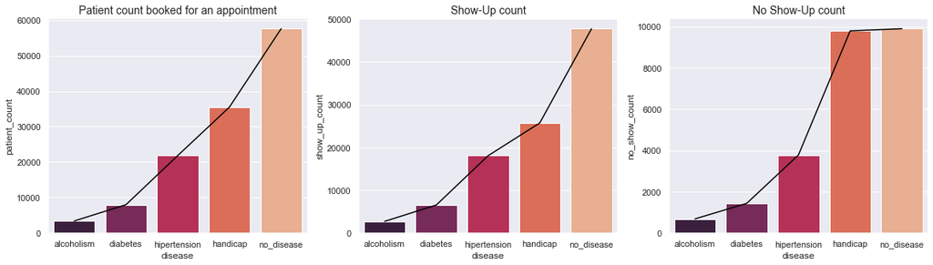

```python
# set background theme as darkgrid
sns.set_theme(style="darkgrid")

# set the figure size
plt.figure(figsize=(20,5))

# Plot the responses for patient counts
plt.subplot(1,3,1)
plt.title('Patient count booked for an appointment', fontsize=14)
sns.lineplot(x=df_dis.disease, y=df_dis.patient_count, color='black')
sns.barplot(x=df_dis.disease, y=df_dis.patient_count, palette="rocket")

# Plot the responses for show up count
plt.subplot(1,3,2)
plt.title('Show-Up count', fontsize=14)
sns.lineplot(x=df_dis.disease, y=df_dis.show_up_count, color='black')
sns.barplot(x=df_dis.disease, y=df_dis.show_up_count, palette="rocket")

# Plot the responses for no-show up count
plt.subplot(1,3,3)
plt.title('No Show-Up count', fontsize=14)
sns.lineplot(x=df_dis.disease, y=df_dis.no_show_count, color='black')
sns.barplot(x=df_dis.disease, y=df_dis.no_show_count, palette="rocket");
```

> **Note :** As the count vary in large amount for show-up and no-show, let us plot the proportions

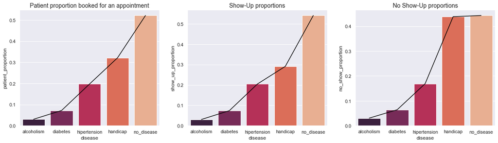

```python
# set the figure size
plt.figure(figsize=(20,5))

# Plot the responses for patient counts proportions
plt.subplot(1,3,1)
plt.title('Patient proportion booked for an appointment', fontsize=14)
sns.lineplot(x=df_dis.disease, y=df_dis.patient_proportion, color='black')
sns.barplot(x=df_dis.disease, y=df_dis.patient_proportion, palette="rocket");

# Plot the responses for show up proportions
plt.subplot(1,3,2)
plt.title('Show-Up proportions', fontsize=14)
sns.lineplot(x=df_dis.disease, y=df_dis.show_up_proportion, color='black')
sns.barplot(x=df_dis.disease, y=df_dis.show_up_proportion, palette="rocket");

# Plot the responses for no-show up count
plt.subplot(1,3,3)
plt.title('No Show-Up proportions', fontsize=14)
sns.lineplot(x=df_dis.disease, y=df_dis.no_show_proportion, color='black')
sns.barplot(x=df_dis.disease, y=df_dis.no_show_proportion, palette="rocket");
```

### Research Question 2 : How does the number of SMS received affects the show-up for scheduled appoinments?

> **Process :**
> - Let's group the dataset by **sms_received** & **no_show**
> - Calculate proportions and load into a DataFrame

```python
# Group the dataset, calculate propotion & load into dataframe
sms_propor = pd.DataFrame((df.groupby(['sms_received','no_show']).size() / df.groupby('sms_received').size()).unstack(level=[1]))
sms_propor
```

| no_show sms_received | 0 | 1 |
| --- | --- | --- |
| 0 | 0.202353 | 0.797647 |
| 1 | 0.179236 | 0.820764 |
| 2 | 0.202186 | 0.797814 |
| 3 | 0.230769 | 0.769231 |
| 4 | 0.333333 | 0.666667 |

```python
# Set the common column name as status & rename each column name
sms_propor.columns.name = 'status'
sms_propor.rename(columns={
    sms_propor.columns[0] :'no_show',
    sms_propor.columns[1] :'show_up'
},inplace=True)
sms_propor
```

| status sms_received | no_show | show_up |
| --- | --- | --- |
| 0 | 0.202353 | 0.797647 |
| 1 | 0.179236 | 0.820764 |
| 2 | 0.202186 | 0.797814 |
| 3 | 0.230769 | 0.769231 |
| 4 | 0.333333 | 0.666667 |

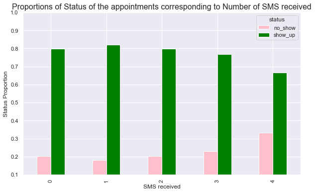

```python
# Plot the response
sms_propor.plot(kind='bar', color=['pink','green'], figsize=(10,6))
plt.title('Proportions of Status of the appointments corresponding to Number of SMS received', fontsize=16)
plt.ylim(0.1,1.0)
plt.xlabel('SMS received')
plt.ylabel('Status Proportion');
```

> - Further Visualisation using heat map

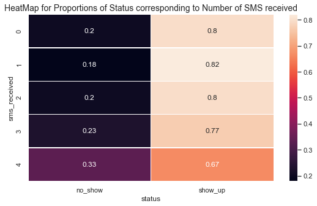

```python
# Heatmap visualisation
plt.figure(figsize=(9,5))
sns.heatmap(sms_propor, annot=True, linewidths=.4)
plt.title('HeatMap for Proportions of Status corresponding to Number of SMS received', fontsize=14);
```

### Research Question 3 : How does Gender affects the No Show occurence?

> **Process :**
> - Group by **gender** & **no_show**
> - Calculate proportion of no_show

```python
# Proportion of no-show & show up by Gender
gen = (df.groupby(['gender','no_show']).size() / df.groupby('gender').size()).reset_index()

# Column names changing
gen.columns = ['gender', 'status', 'proportion']

# Converting 0 & 1 to corresponding status value
gen.status = gen.status.apply(lambda x : 'no_show' if x==0 else 'show_up')
gen
```

|  | gender | status | proportion |
| --- | --- | --- | --- |
| 0 | F | no_show | 0.203146 |
| 1 | F | show_up | 0.796854 |
| 2 | M | no_show | 0.199679 |
| 3 | M | show_up | 0.800321 |

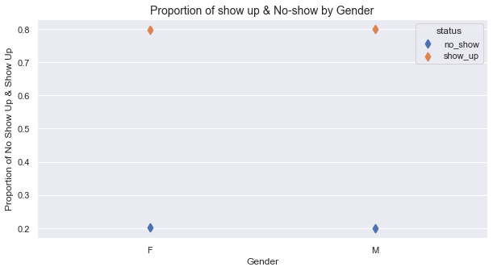

```python
# Plot the responses using pointplot
plt.figure(figsize=(10,5))
sns.pointplot(data=gen, x='gender', y='proportion',hue='status', join=False, markers="d", palatte='dark')
plt.title('Proportion of show up & No-show by Gender', fontsize=14)
plt.xlabel('Gender')
plt.ylabel('Proportion of No Show Up & Show Up');
```

> **conclusion :**
> - We can see that Proportions of 'Female' & 'Male' for both no-show & show-up are almost **equal**
> - It is clear that 'Gender' **doesn't influence** the No Show occurence

### Research Question 4 : How does Scholarship affects the No Show occurence?

> **Process :**
> - Group by **scholarship** & **no_show**
> - Calculate proportion of no_show

```python
# Proportion of no-show & show up by scholarship
scho = (df.groupby(['scholarship','no_show']).size() / df.groupby('scholarship').size()).reset_index()

# Column names changing
scho.columns = ['scholarship', 'status', 'proportion']

# Converting 0 & 1 to corresponding status value
scho.status = scho.status.apply(lambda x : 'no_show' if x==0 else 'show_up')
scho.scholarship = scho.scholarship.apply(lambda x : 'No' if x==0 else 'Yes')

scho
```

|  | scholarship | status | proportion |
| --- | --- | --- | --- |
| 0 | No | no_show | 0.198072 |
| 1 | No | show_up | 0.801928 |
| 2 | Yes | no_show | 0.237363 |
| 3 | Yes | show_up | 0.762637 |

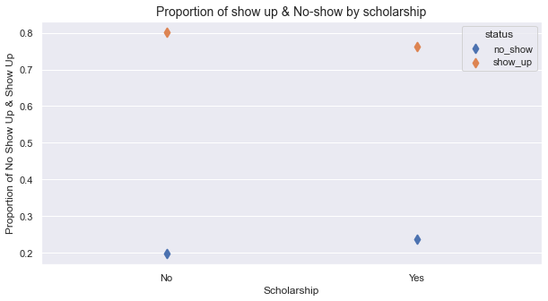

```python
# Plot the responses using pointplot
plt.figure(figsize=(10,5))
sns.pointplot(data=scho, x='scholarship', y='proportion',hue='status', join=False, markers="d", palatte='dark')
plt.title('Proportion of show up & No-show by scholarship', fontsize=14)
plt.xlabel('Scholarship')
plt.ylabel('Proportion of No Show Up & Show Up');
```

> **conclusion :**
> - We can see that patient's having Scholarship tends to have **higher** No Show-up rate

### Research Question 5 : How does Age affects the No Show rate?

> **Process :**
> - Categorize age into different groups
> - Calculate the proportion for each age category

```python
df.age.describe()
```

```
count    110527.000000
mean         38.273933
std          22.104720
min           1.000000
25%          20.000000
50%          37.000000
75%          55.000000
max         115.000000
Name: age, dtype: float64
```

> We can classify the age groups as,
> - **children :** 1-14 years
> - **youth :** 15-24 years
> - **adult :** 25-64 years
> - **seniors :** above 65 years

```python
# categorize age
bins = np.array([ 1, 15, 25, 65, 116])
df['age_category'] = pd.cut(df.age, bins=bins, labels=['children', 'youth', 'adult', 'senior'], right=False)
```

```python
# Proportion calculation
age_cat = (df.groupby(['age_category','gender', 'no_show']).size()/df.groupby(['age_category','gender']).size()).reset_index()

# Column names changing
age_cat.columns = ['age_category', 'gender', 'status', 'proportion']

# Converting 0 & 1 to corresponding status value
age_cat.status = age_cat.status.apply(lambda x : 'no_show' if x==0 else 'show_up')
age_cat
```

|  | age_category | gender | status | proportion |
| --- | --- | --- | --- | --- |
| 0 | children | F | no_show | 0.216818 |
| 1 | children | F | show_up | 0.783182 |
| 2 | children | M | no_show | 0.217969 |
| 3 | children | M | show_up | 0.782031 |
| 4 | youth | F | no_show | 0.251204 |
| 5 | youth | F | show_up | 0.748796 |
| 6 | youth | M | no_show | 0.256303 |
| 7 | youth | M | show_up | 0.743697 |
| 8 | adult | F | no_show | 0.199569 |
| 9 | adult | F | show_up | 0.800431 |
| 10 | adult | M | no_show | 0.189751 |
| 11 | adult | M | show_up | 0.810249 |
| 12 | senior | F | no_show | 0.156215 |
| 13 | senior | F | show_up | 0.843785 |
| 14 | senior | M | no_show | 0.152633 |
| 15 | senior | M | show_up | 0.847367 |

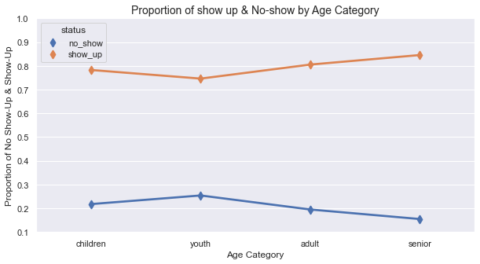

```python
# Plot the responses using pointplot
plt.figure(figsize=(10,5))
sns.pointplot(data=age_cat, x='age_category', y='proportion',hue='status', markers="d", palatte='dark')
plt.title('Proportion of show up & No-show by Age Category', fontsize=14)
plt.ylim(0.1, 1.0)
plt.ylabel('Proportion of No Show-Up & Show-Up')
plt.xlabel('Age Category');
```

> - **Youth** has the highest No Show-Up rate
> - **Seniors** have the highest Show-Up rate

> Now, let's plot with Gender details for each Age group

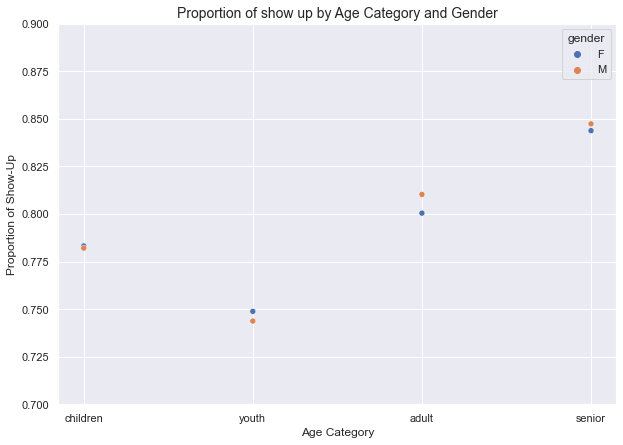

```python
# Plot with gender & age group details
plt.figure(figsize=(10,7))
sns.scatterplot(x="age_category", y="proportion",
                hue="gender", data=age_cat)
plt.title('Proportion of show up by Age Category and Gender', fontsize=14)
plt.ylim(0.7, 0.9)
plt.ylabel('Proportion of Show-Up')
plt.xlabel('Age Category');
```

> - In adult & seniors, **Males** have **Show-Up** rate slightly higher than Females
> - While in youth, **Males** have slightly lower **Show-Up** rate than Females

```python
# Group by age
age = (df.groupby(['age','gender','no_show']).size()/df.groupby(['age','gender']).size()).reset_index()

# Column names changing
age.columns = ['age', 'gender', 'status', 'proportion']

# Converting 0 & 1 to corresponding status value
age.status = age.status.apply(lambda x : 'no_show' if x==0 else 'show_up')
age
```

|  | age | gender | status | proportion |
| --- | --- | --- | --- | --- |
| 0 | 1 | F | no_show | 0.185662 |
| 1 | 1 | F | show_up | 0.814338 |
| 2 | 1 | M | no_show | 0.179747 |
| 3 | 1 | M | show_up | 0.820253 |
| 4 | 2 | F | no_show | 0.146631 |
| ... | ... | ... | ... | ... |
| 391 | 100 | F | show_up | 1.000000 |
| 392 | 100 | M | show_up | 1.000000 |
| 393 | 102 | F | show_up | 1.000000 |
| 394 | 115 | F | no_show | 0.600000 |
| 395 | 115 | F | show_up | 0.400000 |

396 rows × 4 columns

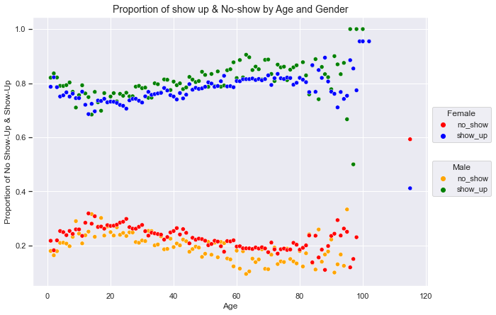

```python
# Plot by Age and Gender
plt.figure(figsize=(10,7))

# Get current axes
ax = plt.gca()
male = sns.scatterplot(x="age", y="proportion",
                hue="status", palette=['orange','green'],
                data=age.query('gender=="M"'), ax=ax)

plt.ylabel('Proportion of No Show-Up & Show-Up')
plt.xlabel('Age')

# Create a twin axis - only use it  for the legend
ax2 = ax.twinx()
female = sns.scatterplot(x="age", y="proportion",
                hue="status", palette=['red','blue'],
                data=age.query('gender=="F"'), ax=ax2)

# Remove the twin y-axis
ax2.get_yaxis().set_visible(False)

# add both legends
ax.legend(loc='center left', bbox_to_anchor=(1, 0.4), title="Male")
ax2.legend(loc='center left', bbox_to_anchor=(1, 0.6), title="Female")

plt.title('Proportion of show up & No-show by Age and Gender', fontsize=14)
plt.ylim(0.0, 1.1);
```

### Research Question 6 : Does the gap between scheduled date and appointment date affect patient's no-show rate?

> **Process :**
> - Let's describe the **awaiting_days** and categorize the gap
> - Create a new column **awaiting_days_category** to store the gap categorizations
> - Calculate the proportion of status of the appointment for each gap

```python
df.awaiting_days.describe()
```

```
count    110527.000000
mean          9.532829
std          15.027683
min           0.000000
25%           0.000000
50%           3.000000
75%          14.000000
max         178.000000
Name: awaiting_days, dtype: float64
```

```python
# Create bins from describe
bins = df.awaiting_days.describe()[['min', '25%', '50%', '75%', 'max']].values
bins[1] = 0.1   # because the 25% quantile is also 0.0 days, need to set to small number so that the cut works

# Create column
df['awaiting_days_category'] = pd.cut(df.awaiting_days, bins=bins, labels=['no_gap', 'short', 'medium', 'long'], right=False)
```

```python
# calculate the proportion of status of the appointment for each gap
days = (df.groupby(['awaiting_days_category','no_show']).size()/df.groupby(['awaiting_days_category']).size()).reset_index()

# Column names changing
days.columns = ['awaiting_days_category', 'status', 'proportion']

# Converting 0 & 1 to corresponding status value
days.status = days.status.apply(lambda x : 'no_show' if x==0 else 'show_up')
days
```

|  | awaiting_days_category | status | proportion |
| --- | --- | --- | --- |
| 0 | no_gap | no_show | 0.066361 |
| 1 | no_gap | show_up | 0.933639 |
| 2 | short | no_show | 0.237693 |
| 3 | short | show_up | 0.762307 |
| 4 | medium | no_show | 0.273497 |
| 5 | medium | show_up | 0.726503 |
| 6 | long | no_show | 0.327481 |
| 7 | long | show_up | 0.672519 |

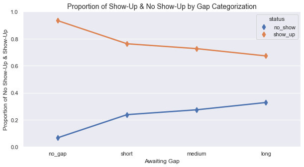

```python
# Plot the responses using pointplot
plt.figure(figsize=(10,5))
sns.pointplot(data=days, x='awaiting_days_category', y='proportion',hue='status', markers="d")
plt.title('Proportion of Show-Up & No Show-Up by Gap Categorization', fontsize=14);
plt.ylim(0.0, 1.0)
plt.ylabel('Proportion of No Show-Up & Show-Up')
plt.xlabel('Awaiting Gap');
```

> **Conclusion :**
> - As we can see, longer the gap between **scheduled_day** and **appointment_day**, no-show rate is **higher**
> - The patients seems to Show Up immediately after booking the appointment, as **No Gap** has the highest show-up rate
> - Even, the no show-up rate of short gap increased significantly compared to no_gap. This may be because patients have changed their mind / got cured

### Research Question 7 : Does the Day of the week affect patient's no-show probability?

> **Process :**
> - Let's create a new column **appointment_weekday** to store the day of the week of **appointment_day**
> - Calculate the proportion of status of the appointment for each weekday

```python
# create new column
df['appointment_weekday'] = df.appointment_day.dt.dayofweek

# print out few lines
df[['appointment_day', 'appointment_weekday']].head()
```

|  | appointment_day | appointment_weekday |
| --- | --- | --- |
| 0 | 2016-04-29 | 4 |
| 1 | 2016-04-29 | 4 |
| 2 | 2016-04-29 | 4 |
| 3 | 2016-04-29 | 4 |
| 4 | 2016-04-29 | 4 |

```python
# calculate the proportion of status of the appointment for each weekday
week_day = (df.groupby(['no_show','appointment_weekday']).size()/df.groupby(['appointment_weekday']).size())
week_day
```

```
no_show  appointment_weekday
0        0                      0.206471
         1                      0.200936
         2                      0.196892
         3                      0.193541
         4                      0.212261
         5                      0.230769
1        0                      0.793529
         1                      0.799064
         2                      0.803108
         3                      0.806459
         4                      0.787739
         5                      0.769231
dtype: float64
```

> Value of weekday corresponds as,
> - 0 - Monday
> - 1 - Tuesday
> - 2 - Wednesday
> - 3 - Thursday
> - 4 - Friday
> - 5 - Saturday
> - 6 - Sunday

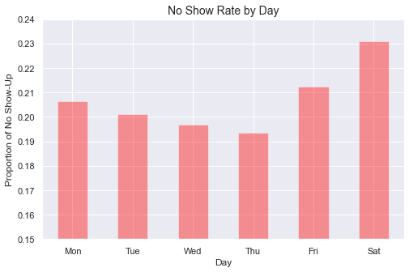

```python
# Plot the response
plt.figure(figsize=(8,5))
week_day[0].plot(kind='bar', color='red', alpha=0.4)
plt.title('No Show Rate by Day', fontsize=14)

# As we have week day value 0-5
labels = ['Mon', 'Tue', 'Wed', 'Thu', 'Fri', 'Sat']
plt.xticks(ticks=range(6), labels=labels, rotation=0)
plt.ylim(0.15, 0.24)
plt.ylabel('Proportion of No Show-Up')
plt.xlabel('Day');
```

> **Conclusion :**
> - We can see that proportion to No show-up rate decreases from Monday to Thursday and again starts increasing, and reach its peak on **Saturday**
> - **Mid-week (Thursday)** is having lowest No show-up rate
> - This may be because of the **higher workload** on initial & end of the week, lower workload in mid-week

## Conclusions

**So, What factors are important for us to know in order to predict if a patient will show up for their scheduled appointment?**

> **Tentatively,**
> - Awaiting days
> - Week Day
> - Age Group
> - Type of disease
> - No.of SMS
> - Scholarship

*Reference websites used in addition to course material,*

- https://www.kaggle.com/joniarroba/noshowappointments
- https://pandas.pydata.org
- https://numpy.org/doc/stable/contents.html
- https://stackoverflow.com
- https://github.com
- https://seaborn.pydata.org/index.html